# Human in the Loop (HITL) Mini Lab

## Background: The Task and Its Challenges

For this lab, we will build upon previous computer vision labs and mini labs with a new dataset and a task that's directly relevant to your professor's research.

Our dataset is a random sample of scanned page images from *The Comics Journal*, an American magazine of news and criticism pertaining to comic books, comic strips and graphic novels published in one form or another since 1976.

Using rule-based methods (dilating, thresholding, edge detection, etc.), I converted these page images into **smaller segments**, each one theoretically representing "a block of content" on a page surrounded by white space. Some of these blocks are very clear chunks of magazine text, such as a paragraph or an entire column, and some of them are illustrations, advertisements, comic strips, etc. There are many things that we might think of as errors, where a partitioned shape was identified but it's actually two separate blocks or part of a larger image that wasn't recognized.

Associate Professor of Philosophy Sam Cowling and I are writing an article about *The Comics Journal* related to the way certain comics are discussed and analyzed, so this project is a spin-off of that work. Our goal is to sort image segments into two categories: segments where only text appears in the image, and segments where anything besides text appears, even if the image is mostly text.

## Setup: The Importance of Folder Locations

Before we start, let's look at how your professor has set up your Github repo. (It turns out, I made some fairly specific decisions, and I had reasons for doing so.) In *HITL Machine Learning*, there's an emphasis on simple labeling interfaces that do the following:

1. Cast your problems as binary choices wherever possible.
2. Ensure that expected responses are diverse to avoid priming.
3. Use existing interaction conventions.
4. Allow keyboard-driven responses. (Monarch 16)

For this mini lab, we don't have time to build a web interface, but our task is simple enough that we can use our file system as a minimal labeling interface. Our unlabeled data is already divided into a `train_test` folder and an `evaluate` folder. I set aside the `evaluate` data before labeling it, as Monarch recommends, because "there are many ways to inadvertently bias your evaluation data after you have started other sampling techniques" (41). After selecting a small `evaluate` sample (n=200), I moved it to subfolders representing the labels. Since we are trying to presort the data into images of "all text" and images with anything besides text, I called my subfolders `only_text_block` and `not_only_text_block`. The rest of the images (n=1500) can be found in the `train_test` folder. They are unlabeled.

As you go through the images, you will "label" files by moving them to folder locations that describe their category (as I demonstrated with the *Calvin & Hobbes* images). You should be able to identify which category an image belongs to and move it to a new location very quickly. (I completed my initial batch of 200 in about 20 minutes).

The core of HITL of Active Learning is to use quantitative methods to decide which images to label by hand. As we do this, we will:

1. Execute code that selects files for human labeling and moves files from the `train_test` folder to a temporary folder called `to_label` (various selection strategies are possible)
2. Execute code that records a log of which active learning iteration we are running, which images were selected, and why each was chosen
3. Label our `to_label` image by hand by moving them to the `only_text_block` and `not_only_text_block` subfolders.
4. Retrain, retest, and reevaluate our model
5. Record the results of the evaluation in our logfile
6. Repeat steps 1-5 using a mix of selection strategies or the same strategy multiple times until some threshold is met (performance reaches a certain point, or X number of images are labeled)

### Question 1

Before doing anything else, complete the following setup:

```python
%matplotlib inline
import os
import os.path
import matplotlib.pyplot as plt
import numpy as np
import pandas as pd
import cv2
import tensorflow as tf
import keras
from keras.applications.imagenet_utils import preprocess_input
from keras.preprocessing import image
from sklearn.metrics import precision_score, recall_score, f1_score, classification_report
import random
import shutil
import glob
```

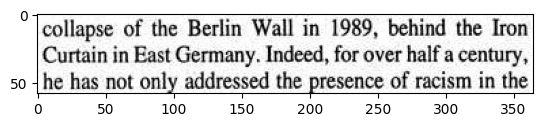

[figure not shown]

[figure not shown]

```python
path_list = ["train_test/April_1995_176_1002942927-i00114_16.jpg", "train_test/February_2008_288_1003063202-i00128_7.jpg", "train_test/February_1997_193_1003063112-i00081_20.jpg"]

for img_path in path_list:
    img = cv2.imread(img_path)
    img_rgb = cv2.cvtColor(img, cv2.COLOR_BGR2RGB)
    plt.imshow(img)
    plt.show()
```

### Question 2

- Describe how you would categorize each of the above image segments and explain your decisions.

## Iteration 1: Select Images

Since we have very few labels, we need to ask what is a big enough sample for our initial model. In our reading, the HITL example starts with 100 labeled text documents for each class label. My first pass of 200 images yielded 140 images belonging to the `only_text_block` class and 60 images belonging to the `not_only_text_block` class. A random sample of 200 more images should yield at least 100 for each class. Since we don't yet have any information about the unlabeled images, we should use random selection.

### Question 3

- Write a function to select 200 random images from the `train_test` folder and move them to the `to_label` folder that you created. We're moving them instead of copying them because we don't want to select any duplicates in a later iteration.
- Your function should return a list of the image you selected so you can save it for later use
- For convenience, call this function `select_and_move_images_random()`
- Define and call your function below

```python
all_images = []

for file in os.listdir("train_test"):
    all_images.append(file)
```

```python
def select_and_move_images_random(count):
    sample_images = random.sample(all_images, count)

    for image in sample_images:
        source_path = os.path.join("train_test", image)
        destination_path = os.path.join("to_label", image)
        shutil.move(source_path, destination_path)

    return sample_images
```

```python
select_and_move_images_random(200)
```

```
['May_1984_90_1003063025-i0097_2.jpg',
 'May_1998_204_1003063121-i00009_2.jpg',
 'August_2005_270_1003063185-i00098_1.jpg',
 'November_2000_228_1003063145-i00047_2.jpg',
 'May_1992_150_1003063078-i00139_4.jpg',
 'July_2005_269_1002862992-i00044_12.jpg',
 'October-November_2004_263_1003063179-i00045_10.jpg',
 'November_2007_286_1003063200-i00177_8.jpg',
 'July_2006_277_1003063192-i00176_4.jpg',
 'July_1982_73_1003063012-i00032_16.jpg',
 'May_2006_276_1003063191-i00163_5.jpg',
 'April_1988_121_1003063055-i00119_11.jpg',
 'July_2007_284_1003063198-i00135_13.jpg',
 'December_1996_192_192-061_15.jpg',
 'November_2009_300_1003063206-i00210_9.jpg',
 'September_2003_255_1003063171-i00089_8.jpg',
 'November_2002_248_1003063165-i00075_4.jpg',
 'April_2006_275_1003063190-i00020_10.jpg',
 'April_1999_211_tcj211019_13.jpg',
 'March_1998_202_1002798202-i00025_20.jpg',
 'August_1995_179_1003063100-i00098_15.jpg',
 'May_1993_159_1003063086-i00012_6.jpg',
 'September_1990_137_1003063069-i00056_8.jpg',
 'March_1993_157_1003063084-i00056_9.jpg',
 'April_2006_275_1003063190-i00020_13.jpg',
 'April_1995_176_1002942927-i00072_9.jpg',
 'April-May_2005_267_untitled-056_18.jpg',
 'May_1986_108_1003063042-i00056_22.jpg',
 'August_1981_66_1003064917-i0031_8.jpg',
 'October_2005_271_1003063186-i00198_16.jpg',
 'November_2005_272_1003063187-i00177_13.jpg',
 'October_1988_125_1003063059-i00036_0_1.jpg',
 'February_1991_140_1003063072-i00091_7.jpg',
 'February_1997_193_1003063112-i00003_8.jpg',
 'August_1992_152_1003063080-i00069_11.jpg',
 'January_2007_280_001-200-200_23.jpg',
 'November_2000_228_1003063145-i00015_8.jpg',
 'July_2004_261_1003063177-i00075_19.jpg',
 'January_2007_280_001-068-68_12.jpg',
 'May_1999_212_1003063129-i00045_8.jpg',
```

[output cut: 145 more lines]

```
 'February_2009_296_1003063204-i00066_5.jpg',
 'July_2008_291_1002798205-i00009_1.jpg',
 'July_2006_277_1003063192-i00131_7.jpg',
 'June_1998_205_205_056_10.jpg',
 'Spring_1981_63_1003063009-i00160_3.jpg',
 'February_2006_274_1003063189-i00072_6.jpg',
 'January_1994_165_1002942952-i00013_2.jpg',
 'December_2008_294_1002798204-i00081_12.jpg',
 'June_2003_253_1002856570-i00014_2.jpg',
 'November_1999_217_1003063134-i00040_5.jpg',
 'February_1991_140_1003063072-i00107_8.jpg',
 'October_2007_285_1003063199-i00139_9.jpg',
 'October_1988_125_1003063059-i00061_0_20.jpg',
 'January_2000_219_1003063136-i00038_24.jpg',
 'October_2005_271_1003063186-i00029_24.jpg']
```

## Iteration 1: "Label" Your Selections

Now we need to label our 200 images. Outside of your Jupyter Notebook, open up the `to_label` folder and look at the images in it. On most computers, you can change your view settings from `list` or `columns` to `icons` or `gallery` so that you can see a preview of each image. As you glance at them, it should be obvious for most of them which images are all text and which images aren't. As you identify them, simply drag each image to the correct subfolder, `only_text_block` or `not_only_text_block`. If you have a hard time classifying an image, open it in Preview, Adobe, etc. and give it a closer look.

## Iteration 1: Image Selection Logfile

Each time we select images for labeling, we will want to write some kind of logfile with information about the selection phase, like this:

| image_filename | actual_label | selection_method |
| --- | --- | --- |
| somefile.png | only_text_block | some_method |
| somefile.png | not_only_text_block | some_method |
| ... | ... | ... |

### Question 4

- Write a chunk of code below to create a `DataFrame` with the above rows and columns, and name your variable `iteration-1-selection`
- For this iteration, we can read the contents of `only_text_block` or `not_only_text_block` respectively and infer their labels from their folder loction. The `selection_method` value for every image should be 'random'.
- Save `iteration-1-selection` to the `selection_log` folder with the filename `iteration-1-selection.csv`
- Display the first ten rows of `iteration-1-selection` below.

**Remember:** Do not use the print() function when displaying DataFrames in a Jupyter Notebook file.

```python
image_filename = []
actual_label = []
selection_method = []

for file in os.listdir("to_label/only_text_block"):
    image_filename.append(file)
    actual_label.append("only_text_block")
    selection_method.append("random")

for file in os.listdir("to_label/not_only_text_block"):
    image_filename.append(file)
    actual_label.append("not_only_text_block")
    selection_method.append("random")

temp_dict = {"image_filename": image_filename, "actual_label": actual_label, "selection_method": selection_method}

iteration_1_selection = pd.DataFrame(temp_dict)

iteration_1_selection.to_csv(os.path.join("selection_log", "iteration-1-selection.csv"), index=False)

iteration_1_selection.head(10)
```

|  | image_filename | actual_label | selection_method |
| --- | --- | --- | --- |
| 0 | April-May_2005_267_untitled-044_6.jpg | only_text_block | random |
| 1 | April-May_2005_267_untitled-056_18.jpg | only_text_block | random |
| 2 | April-May_2005_267_untitled-056_23.jpg | only_text_block | random |
| 3 | April-May_2005_267_untitled-056_24.jpg | only_text_block | random |
| 4 | April-May_2005_267_untitled-153_12.jpg | only_text_block | random |
| 5 | April_1977_33_1003062993-i00025_21.jpg | only_text_block | random |
| 6 | April_1986_107_1003063041-i0082_9.jpg | only_text_block | random |
| 7 | April_1991_141_1003063073-i00007_4.jpg | only_text_block | random |
| 8 | April_1995_176_1002942927-i00072_9.jpg | only_text_block | random |
| 9 | April_1998_203_1003063120-i00039_9.jpg | only_text_block | random |

## Iteration 1: Learn from New Data

Now we need to stop and estimate at our class balancing, as our next rounds of annotation will not be random samples.

### Question 5

- Write some code to count how many images of each class we have, and to estimate the ratio of `only_text_block` segments to `not_only_text_block` segments.
- Lastly, how can we estimate the sampling error of this ratio? Make sure your code displays the ratio estimate and the estimated sampling error below.

```python
only_count = len(iteration_1_selection[iteration_1_selection["actual_label"] == "only_text_block"])
not_only_count = len(iteration_1_selection[iteration_1_selection["actual_label"] == "not_only_text_block"])

sample_ratio = only_count / not_only_count
sampling_error = (1 / only_count) + (1 / not_only_count)

print("\nRatio of 'only_text_block' segments to 'not_only_text_block' segments:")
print(sample_ratio)
print("\nEstimated sampling error:")
print(sampling_error)
```

```
Ratio of 'only_text_block' segments to 'not_only_text_block' segments:
2.6363636363636362

Estimated sampling error:
0.025078369905956112
```

## Iteration 1: Train, Test, and Evaluate

Finally, we can train and test our first machine learning model.

### Question 6

Write code below to do the following:

1. load all the images for which we have labels
2. set up a binary image classifier (tensorflow CNN with a sigmoid function)
3. create a train/test split of the data
4. train your model and test it (applying your inferred class balance)
5. evaluate model performance by looking at the precision, recall, and f1 scores for both classes
6. make sure your code block below prints all of your performance benchmarks

```python
model = tf.keras.models.Sequential([
    # Note the input shape is the desired size of the image 200x200 with 3 bytes color
    # The first convolution
    tf.keras.layers.Conv2D(32, (3,3), activation='relu', input_shape=(200, 200, 3)),
    tf.keras.layers.MaxPooling2D(2, 2),
    tf.keras.layers.Dropout(0.25),
    # The second convolution
    tf.keras.layers.Conv2D(32, (3,3), activation='relu'),
    tf.keras.layers.MaxPooling2D(2,2),
    tf.keras.layers.Dropout(0.25),
    # The third convolution
    tf.keras.layers.Conv2D(64, (3,3), activation='relu'),
    tf.keras.layers.MaxPooling2D(2,2),
    tf.keras.layers.Dropout(0.25),
    # Flatten the results to feed into a DNN
    tf.keras.layers.Flatten(),
    # 512 neuron hidden layer
    tf.keras.layers.Dense(512, activation='relu'),
    # Only 1 output neuron. It will contain a value from 0-1
    tf.keras.layers.Dense(1, activation='sigmoid')])

RMSprop = tf.keras.dtensor.experimental.optimizers.RMSprop
model.compile(loss='binary_crossentropy',optimizer=RMSprop(),metrics='accuracy')

training_set = tf.keras.utils.image_dataset_from_directory(
        "to_label",
        seed=123,
        image_size=(200, 200),
        subset='training',
        validation_split=0.3,
        batch_size=5)

validation_set = tf.keras.utils.image_dataset_from_directory(
        "to_label",
        shuffle=True,
        seed=17,
        image_size=(200, 200),
        validation_split=0.3,
        subset='validation',
        batch_size=5)

holdout_set_all = tf.keras.utils.image_dataset_from_directory(
        "to_label",
        shuffle=False,
        seed=17,
        image_size=(200, 200),
        batch_size=1) # batch size has to be one for this set

# Extracting file paths from datasets for further processing
train_file_paths = training_set.file_paths
validation_file_paths = validation_set.file_paths
holdout_file_paths = holdout_set_all.file_paths

# Extracting images and labels from the holdout set for later use
images = []
image_name = []
labels = []
label_name = []
for e, image_label in enumerate(holdout_set_all):
        f = holdout_file_paths[e]
        if f in validation_file_paths:
                images.append(image_label[0].numpy())
                image_name.append(f.split("\\")[2])
                labels.append(image_label[1].numpy())
                label_name.append(f.split("\\")[1])

# Fitting the model to the training data and validating it on the validation set
history = model.fit(training_set,
        epochs=9,
        verbose=0,
        validation_data = validation_set)

eval_score = model.evaluate(validation_set)
print('\nTest loss:', eval_score[0])
print('\nTest accuracy:', eval_score[1])

# Predicting labels for images in the holdout set
img_arrays = []
for i in images:
        img_arrays.append(i)

test_dataset = tf.data.Dataset.from_tensor_slices(img_arrays)
preds = model.predict(test_dataset)
preds_classification = (preds > 0.3).astype('int32').flatten()

# Counting occurrences of each label in the holdout set
from collections import Counter
c = Counter([i[0] for i in labels])

df = pd.DataFrame()
df['image_filename'] = image_name
df['label'] = label_name
df['true_label'] = [i[0] for i in labels]
df['predict_probability'] = [i[0] for i in preds]
df = df.sort_values(by='predict_probability')
inferred_labels = [0 for i in range(c[0])] + [1 for i in range(c[1])]
df['predicted_label'] = inferred_labels
df['compare'] = df['true_label'] == df['predicted_label']

# Calculating precision, recall, and f1 scores
true_labels = df['true_label'].to_numpy()
predicted_labels = df['predicted_label'].to_numpy()

precision = precision_score(true_labels, predicted_labels, average=None)
recall = recall_score(true_labels, predicted_labels, average=None)
f1 = f1_score(true_labels, predicted_labels, average=None)

print("\nPrecision score of the model:")
print(precision)
print("\nRecall score of the model:")
print(recall)
print("\nF1 score of the model:")
print(f1)
```

```
Found 200 files belonging to 2 classes.
Using 140 files for training.
Found 200 files belonging to 2 classes.
Using 60 files for validation.
Found 200 files belonging to 2 classes.

Test loss: 0.583825945854187

Test accuracy: 0.7666666507720947

Precision score of the model:
[0.45454545 0.68421053]

Recall score of the model:
[0.45454545 0.68421053]

F1 score of the model:
[0.45454545 0.68421053]
```

## Iteration 1: Record Results

Before moving to the second iteration, we want to take a snapshot of the currently labeled data, and how it performed, so that we can track the model's improvement (hopefully) with later iterations. AS with the image selection log, let's work backwards from the kind of logfile we want to generate:

| image_filename | train_test | predicted_label | actual_label | correct |
| --- | --- | --- | --- | --- |
| somefile.png | train | NA | only_text_block | NA |
| somefile.png | test | only_text_block | only_text_block | True |
| somefile.png | test | not_only_text_block | only_text_block | False |

This kind of logfile would list every labeled image in our current setup, as well as whether it ended up in the training data vs test data and finally, for test set data, whether it was correctly categorized by our model.

### Question 7

- Construct a pandas `DataFrame` with rows and columns as seen above, and name the variable `iteration-1-eval`
- Write the `DataFrame` to a CSV file called `iteration-1-eval.csv` and save it to the `eval` folder
- Display the first ten rows of `iteration-1-eval` below

```python
train_filenames = []
for i in range(len(train_file_paths)):
    train_filenames.append(train_file_paths[i].split("\\")[2])
```

```python
test_filenames = []
for i in range(len(validation_file_paths)):
    test_filenames.append(validation_file_paths[i].split("\\")[2])
```

```python
predicted_label_name = []
for i in range(len(df["image_filename"])):
    if (df["predicted_label"][i] == 0):
        predicted_label_name.append("not_only_text_block")
    else:
        predicted_label_name.append("only_text_block")

train_test_label = []
for i in image_name:
    if i in train_filenames:
        train_test_label.append("train")
    elif i in test_filenames:
        train_test_label.append("test")

iteration_1_eval = pd.DataFrame()

iteration_1_eval["image_filename"] = image_name
iteration_1_eval["train_test"] = train_test_label
iteration_1_eval["predicted_label"] = predicted_label_name
iteration_1_eval["actual_label"] = label_name
iteration_1_eval["correct"] = iteration_1_eval['predicted_label'] == iteration_1_eval['actual_label']
```

```python
iteration_1_eval.to_csv(os.path.join("eval", "iteration-1-eval.csv"), index=False)
```

```python
iteration_1_eval.head(10)
```

|  | image_filename | train_test | predicted_label | actual_label | correct |
| --- | --- | --- | --- | --- | --- |
| 0 | April_1999_211_tcj221088_1.jpg | test | only_text_block | not_only_text_block | False |
| 1 | August_2005_270_1003063185-i00100_1.jpg | train | only_text_block | not_only_text_block | False |
| 2 | December_1996_192_192-061_15.jpg | train | not_only_text_block | not_only_text_block | True |
| 3 | December_2008_294_1002798204-i00081_12.jpg | train | not_only_text_block | not_only_text_block | True |
| 4 | February_1990_134_1003063067-i00042_2.jpg | train | not_only_text_block | not_only_text_block | True |
| 5 | February_1991_140_1003063072-i00107_8.jpg | train | only_text_block | not_only_text_block | False |
| 6 | February_2007_281_1002856641-i00045_14.jpg | test | only_text_block | not_only_text_block | False |
| 7 | February_2008_288_1003063202-i00045_9.jpg | test | only_text_block | not_only_text_block | False |
| 8 | January_2007_280_001-197-197_10.jpg | train | not_only_text_block | not_only_text_block | True |
| 9 | July_1984_91_1003063026-i00096_4.jpg | train | not_only_text_block | not_only_text_block | True |

## Iteration 2: Select Images

Now it's time to see if active learning can help us "specify how you elicit training data from people and determine the right data to put in front of people when you don't have the budget or time for human feedback on all your data" (4). To make use of active learning strategies, we will create new batches of images to label based on uncertainty sampling, diversity sampling, and a bit of random chance so that "every data item still has some chance of being selected randomly and being reviewed by a human, even if none of the sampling strategies would have selected it" (44). In the book, Monarch recommends each iteration be composed of:

- 10% randomly selected from unlabeled items
- 80% selected from the lowest confidence items
- 10% selected as outliers

1. a way to create a random sample of images from `train_test` and move them to `to_label`, but we already have the `select_and_move_images_random` function from our first iteration. We just need to make sure our function can accept a sample size as an argument since our sample size here will be 25, not 200.
2. a way to load all the images the `train_test` folder, make predictions about their class labels, and move the most ambiguous 160 images to the `to_label` folder.
3. a way to identify outliers in the data and move the 25 most significant outliers to the `to_label` folder.

### Question 8

Write and run code below for the following operations:

1. Use your `select_and_move_images_random()` function to select 25 image at random from `train_test` and move them to the `to_label` folder
2. Train your CNN model on labeled data and make predictions for all images remaining in the `train_test` folder
3. Write code that moves the most ambiguous 160 images to the `to_label` folder
4. Write code that moves the 25 images with the strongest predicted probability scores (for either category) to the `to_label` folder
5. Store all selection data for your selection log

```python
sample_images_2 = select_and_move_images_random(25)
```

```python
def load_images_for_neural_network(fnames, batch_size):
    print(len(fnames))
    while True:
        cfns = []
        for i, p in enumerate(fnames):
            cfns.append(p)
            if len(cfns) == batch_size:
                yield load_images_keras(cfns)
                cfns = []
        if len(cfns) != 0:
            yield load_images_keras(cfns)
            cfns = []

def load_images_keras(image_list):
    images = []
    for i in image_list:
        this_pil = image.load_img(i, target_size = (200, 200))
        this_array = image.img_to_array(this_pil)
        c_img = np.expand_dims(this_array, axis = 0)
        images.append(c_img)
    return preprocess_input(np.vstack(images))
```

```python
segment = glob.glob("train_test/*")
batch_size = 1
model_preds = []

segment_generator = load_images_for_neural_network(segment, batch_size)
predictions = model.predict(segment_generator, steps = len(segment) // batch_size, verbose=1)
```

```
1275
```

```python
ambiguous_image_id = np.concatenate(np.absolute(predictions-0.5)).argsort()[:160].tolist()
ambiguous_images = [segment[i].split("\\")[-1] for i in ambiguous_image_id]

for image in ambiguous_images:
        source_path = os.path.join("train_test", image)
        destination_path = os.path.join("to_label", image)
        shutil.move(source_path, destination_path)
```

```python
strongest_image_id = np.concatenate(np.absolute(predictions-0.5)).argsort()[-25:].tolist()
strongest_images = [segment[i].split("\\")[-1] for i in strongest_image_id]

for image in strongest_images:
        source_path = os.path.join("train_test", image)
        destination_path = os.path.join("to_label", image)
        shutil.move(source_path, destination_path)
```

## Iteration 2: Label and Record

As with Iteration 1, we need to label all the data in our `to_label` folder by moving it to the appropriate subfolder.

### Question 11

- When you've finished moving images to their appropriate subfolders, write a chunk of code below to create a selection log `DataFrame` (as you did with question 4), and name your variable `iteration-2-selection`
- For this iteration, we need a more nuanced way to record the `selection_method` value, since some of our images would be labeled `random`, `ambiguous`, or `outlier`
- Save `iteration-2-selection` to the `selection_log` folder with the filename `iteration-2-selection.csv`
- Display the first ten rows of `iteration-2-selection` below

```python
image_filename = []
actual_label = []
selection_method = []

iteration_1_filename = iteration_1_selection["image_filename"].to_list()

for file in os.listdir("to_label/only_text_block"):
    if file not in iteration_1_filename:
        image_filename.append(file)
        actual_label.append("only_text_block")

for file in os.listdir("to_label/not_only_text_block"):
    if file not in iteration_1_filename:
        image_filename.append(file)
        actual_label.append("not_only_text_block")

for filename in image_filename:
    if filename in sample_images_2:
        selection_method.append("random")
    elif filename in ambiguous_images:
        selection_method.append("ambiguous")
    elif filename in strongest_images:
        selection_method.append("outlier")

temp_dict = {"image_filename": image_filename, "actual_label": actual_label, "selection_method": selection_method}

iteration_2_selection = pd.DataFrame(temp_dict)

iteration_2_selection.to_csv(os.path.join("selection_log", "iteration-1-selection.csv"), index=False)

iteration_2_selection.head(10)
```

|  | image_filename | actual_label | selection_method |
| --- | --- | --- | --- |
| 0 | April_1999_211_tcj211003_1.jpg | only_text_block | ambiguous |
| 1 | April_1999_211_tcj211003_2.jpg | only_text_block | random |
| 2 | April_1999_211_tcj211019_11.jpg | only_text_block | ambiguous |
| 3 | August-September_2004_262_1003063178-i00095_6.jpg | only_text_block | random |
| 4 | August_1988_124_1003063058-i0021_12.jpg | only_text_block | ambiguous |
| 5 | August_1988_124_1003063058-i0021_9.jpg | only_text_block | ambiguous |
| 6 | August_2000_226_1003063143-i00006_3.jpg | only_text_block | ambiguous |
| 7 | December_1990_139_1003063071-i00120_7.jpg | only_text_block | ambiguous |
| 8 | December_1991_147_1003063076-i00054_11.jpg | only_text_block | ambiguous |
| 9 | December_1991_147_1003063076-i00054_15.jpg | only_text_block | ambiguous |

```python
iteration_2_selection.to_csv(os.path.join("selection_log", "iteration-2-selection.csv"), index=False)
```

### Question 12

Repeating all of the steps from Question 6, train and test your machine learning model using the full set of labeled images for which we have labels:

1. load all the images for which we have labels
2. set up a binary image classifier (tensorflow CNN with a sigmoid function)
3. create a train/test split of the data
4. train your model and test it (applying your inferred class balance)
5. evaluate model performance by looking at the precision, recall, and f1 scores for both classes
6. make sure your code block below prints all of your performance benchmarks

```python
model = tf.keras.models.Sequential([
    # Note the input shape is the desired size of the image 200x200 with 3 bytes color
    # The first convolution
    tf.keras.layers.Conv2D(32, (3,3), activation='relu', input_shape=(200, 200, 3)),
    tf.keras.layers.MaxPooling2D(2, 2),
    tf.keras.layers.Dropout(0.25),
    # The second convolution
    tf.keras.layers.Conv2D(32, (3,3), activation='relu'),
    tf.keras.layers.MaxPooling2D(2,2),
    tf.keras.layers.Dropout(0.25),
    # The third convolution
    tf.keras.layers.Conv2D(64, (3,3), activation='relu'),
    tf.keras.layers.MaxPooling2D(2,2),
    tf.keras.layers.Dropout(0.25),
    # Flatten the results to feed into a DNN
    tf.keras.layers.Flatten(),
    # 512 neuron hidden layer
    tf.keras.layers.Dense(512, activation='relu'),
    # Only 1 output neuron. It will contain a value from 0-1
    tf.keras.layers.Dense(1, activation='sigmoid')])

RMSprop = tf.keras.dtensor.experimental.optimizers.RMSprop
model.compile(loss='binary_crossentropy',optimizer=RMSprop(),metrics='accuracy')

training_set = tf.keras.utils.image_dataset_from_directory(
        "to_label",
        seed=123,
        image_size=(200, 200),
        subset='training',
        validation_split=0.3,
        batch_size=5)

validation_set = tf.keras.utils.image_dataset_from_directory(
        "to_label",
        shuffle=True,
        seed=17,
        image_size=(200, 200),
        validation_split=0.3,
        subset='validation',
        batch_size=5)

holdout_set_all = tf.keras.utils.image_dataset_from_directory(
        "to_label",
        shuffle=False,
        seed=17,
        image_size=(200, 200),
        batch_size=1) # batch size has to be one for this set

# Extracting file paths from datasets for further processing
train_file_paths = training_set.file_paths
validation_file_paths = validation_set.file_paths
holdout_file_paths = holdout_set_all.file_paths

# Extracting images and labels from the holdout set for later use
images = []
image_name = []
labels = []
label_name = []
for e, image_label in enumerate(holdout_set_all):
        f = holdout_file_paths[e]
        if f in validation_file_paths:
                images.append(image_label[0].numpy())
                image_name.append(f.split("\\")[2])
                labels.append(image_label[1].numpy())
                label_name.append(f.split("\\")[1])

# Fitting the model to the training data and validating it on the validation set
history = model.fit(training_set,
        epochs=9,
        verbose=0,
        validation_data = validation_set)

eval_score = model.evaluate(validation_set)
print('\nTest loss:', eval_score[0])
print('\nTest accuracy:', eval_score[1])

# Predicting labels for images in the holdout set
img_arrays = []
for i in images:
        img_arrays.append(i)

test_dataset = tf.data.Dataset.from_tensor_slices(img_arrays)
preds = model.predict(test_dataset)
preds_classification = (preds > 0.3).astype('int32').flatten()

# Counting occurrences of each label in the holdout set
from collections import Counter
c = Counter([i[0] for i in labels])

df = pd.DataFrame()
df['image_filename'] = image_name
df['label'] = label_name
df['true_label'] = [i[0] for i in labels]
df['predict_probability'] = [i[0] for i in preds]
df = df.sort_values(by='predict_probability')
inferred_labels = [0 for i in range(c[0])] + [1 for i in range(c[1])]
df['predicted_label'] = inferred_labels
df['compare'] = df['true_label'] == df['predicted_label']

# Calculating precision, recall, and f1 scores
true_labels = df['true_label'].to_numpy()
predicted_labels = df['predicted_label'].to_numpy()

precision = precision_score(true_labels, predicted_labels, average=None)
recall = recall_score(true_labels, predicted_labels, average=None)
f1 = f1_score(true_labels, predicted_labels, average=None)

print("\nPrecision score of the model:")
print(precision)
print("\nRecall score of the model:")
print(recall)
print("\nF1 score of the model:")
print(f1)
```

```
Found 410 files belonging to 2 classes.
Using 287 files for training.
Found 410 files belonging to 2 classes.
Using 123 files for validation.
Found 410 files belonging to 2 classes.

Test loss: 0.4727983772754669

Test accuracy: 0.934959352016449

Precision score of the model:
[0.8125     0.93406593]

Recall score of the model:
[0.8125     0.93406593]

F1 score of the model:
[0.8125     0.93406593]
```

### Question 13

Normally, we'd do a few more iterations and see where we are around the 800-1000 images mark, but this is a mini lab! Instead, let's consider an alternative method for isolating outliers in our data. One thing Monarch talks about is training a completely different model to do the same task, and then isolating the outliers from that model. Knowing what we know about `scikit-learn`, `opencv`, and `tensorflow`, describe an approach we could take to employ this strategy. Be specific about the kind of model, how we would define/isolate outliers, and what kinds of outliers your choice of model might find.

We can use ResNet50 as a model to convert images to representation vectors. One common model for anomaly detection is the Isolation Forest algorithm, which is available in scikit-learn. Isolation Forest is effective at identifying outliers that deviate significantly from the majority of the data points. These outliers may represent anomalies, errors, or rare events in the dataset. Thus, we can complement the predictions from the primary classification model and potentially identify instances that are difficult to classify or that exhibit unusual characteristics not captured by the primary model.

## Evaluation

### Question 14

Our last step is to record our model performance after the second iteration. Similar to question 7 above, complete the following steps:

- Construct a pandas `DataFrame` for your evaluation log with the same rows and columns as question 7, but this time name your variable `iteration-2-eval`
- Write the `DataFrame` to a CSV file called `iteration-2-eval.csv` and make sure you save it in the `eval` folder
- Display the first ten rows of `iteration-2-eval`

```python
train_filenames = []
for i in range(len(train_file_paths)):
    train_filenames.append(train_file_paths[i].split("\\")[2])

test_filenames = []
for i in range(len(validation_file_paths)):
    test_filenames.append(validation_file_paths[i].split("\\")[2])

predicted_label_name = []
for i in range(len(df["predicted_label"])):
    if (df["predicted_label"][i] == 0):
        predicted_label_name.append("not_only_text_block")
    else:
        predicted_label_name.append("only_text_block")

train_test_label = []
for i in image_name:
    if i in train_filenames:
        train_test_label.append("train")
    elif i in test_filenames:
        train_test_label.append("test")

iteration_2_eval = pd.DataFrame()

iteration_2_eval["image_filename"] = image_name
iteration_2_eval["train_test"] = train_test_label
iteration_2_eval["predicted_label"] = predicted_label_name
iteration_2_eval["actual_label"] = label_name
iteration_2_eval["correct"] = iteration_2_eval['predicted_label'] == iteration_2_eval['actual_label']
```

```python
iteration_2_eval.to_csv(os.path.join("eval", "iteration-2-eval.csv"), index=False)
```

```python
iteration_2_eval.head(10)
```

|  | image_filename | train_test | predicted_label | actual_label | correct |
| --- | --- | --- | --- | --- | --- |
| 0 | April_1998_203_1003063120-i00081_9.jpg | test | not_only_text_block | not_only_text_block | True |
| 1 | April_1999_211_tcj221063_10.jpg | train | not_only_text_block | not_only_text_block | True |
| 2 | April_2000_222_1003063139-i00001_5.jpg | train | not_only_text_block | not_only_text_block | True |
| 3 | April_2000_222_1003063139-i00001_7.jpg | test | not_only_text_block | not_only_text_block | True |
| 4 | August_1981_66_1003064917-i0022_7.jpg | train | not_only_text_block | not_only_text_block | True |
| 5 | August_1992_152_1003063080-i00069_15.jpg | train | only_text_block | not_only_text_block | False |
| 6 | December_2008_294_1002798204-i00113_10.jpg | test | only_text_block | not_only_text_block | False |
| 7 | February_1991_140_1003063072-i00073_4.jpg | train | not_only_text_block | not_only_text_block | True |
| 8 | February_1995_174_1003063096-i00039_10.jpg | train | not_only_text_block | not_only_text_block | True |
| 9 | February_2007_281_1002856641-i00045_14.jpg | train | not_only_text_block | not_only_text_block | True |

### Question 15

Interpret your model's performance below, as well, as how it changed over the course of the lab. Were our active learning strategies successful? Why or why not?

Performance scores for iteration 1:

- Precision score of the model: [0.45454545 0.68421053]
- Recall score of the model: [0.45454545 0.68421053]
- F1 score of the model: [0.45454545 0.68421053]

Perfomance scores for iteration 2:

- Precision score of the model: [0.8125 0.93406593]
- Recall score of the model: [0.8125 0.93406593]
- F1 score of the model: [0.8125 0.93406593]

In iteration 1, the model's performance was relatively low in precision, recall, and F1 scores for both classes. This indicates that the model had difficulty distinguishing between the two classes and was not performing well overall. In contrast, in iteration 2, the model's performance improved significantly. The precision, recall, and F1 scores increased significantly for both classes. This means that the model became more accurate and reliable in classifying the images after implementing active learning strategies.

In conclusion, the active learning strategies implemented in iteration 2 were successful in enhancing the model's performance.